# super_bowl

olayinka ogunneye

2025-02-25

### Introduction

The Super Bowl is one of the biggest annual sporting events, bringing together massive TV viewership, big-budget advertisements, and highly anticipated halftime performances. In this analysis, I focus on **modern Super Bowls** (Super Bowl from 1987 to 2024) to explore:

- Whether large point differences lead to lost viewership.
- How TV viewership, ratings, and advertisement costs have trended over time.
- Whether the number of songs performed during the halftime show correlates with higher viewership.
- Which halftime performances were the most elaborate (in terms of songs) and how they compare to TV ratings.
- Which Super Bowl had the highest rated halftime show.

The data for this project comes from three CSV files:

**super_bowls.csv**: Contains Super Bowl game data (including super_bowl number and difference_pts).

**tv.csv** : Contains TV metrics such as avg_us_viewers, rating_household, ad_cost, and share_household.

**halftime_musicians.csv** : Contains data on the musicians performing at halftime, including num_songs.

I will limit the dataset to Super Bowls greater than 20 (i.e., from 1987 onwards) to examine more modern games.

#### Load Data

```r
# Load CSV data

super_bowls <- read_csv("C:/Users/olayi/Desktop/Data/R/R Projects/Superbowl/datasets/super_bowls.csv")
tv <- read_csv("C:/Users/olayi/Desktop/Data/R/R Projects/Superbowl/datasets/tv.csv")
halftime_musicians <- read_csv("C:/Users/olayi/Desktop/Data/R/R Projects/Superbowl/datasets/halftime_musicians.csv")
# Inspect the loaded data
print(super_bowls)
```

```
## # A tibble: 58 × 18
##    date       super_bowl venue    city  state attendance team_winner winning_pts
##    <date>          <dbl> <chr>    <chr> <chr>      <dbl> <chr>             <dbl>
##  1 2024-02-11         58 Allegia… Para… Neva…      61629 Kansas Cit…          25
##  2 2023-02-12         57 State F… Glen… Ariz…      67827 Kansas Cit…          38
##  3 2022-02-13         56 SoFi St… Ingl… Cali…      70048 Los Angele…          23
##  4 2021-02-07         55 Raymond… Tampa Flor…      24835 Tampa Bay …          31
##  5 2020-02-02         54 Hard Ro… Miam… Flor…      62417 Kansas Cit…          31
##  6 2019-02-03         53 Mercede… Atla… Geor…      70081 New Englan…          13
##  7 2018-02-04         52 U.S. Ba… Minn… Minn…      67612 Philadelph…          41
##  8 2017-02-05         51 NRG Sta… Hous… Texas      70807 New Englan…          34
##  9 2016-02-07         50 Levi's … Sant… Cali…      71088 Denver Bro…          24
## 10 2015-02-01         49 Univers… Glen… Ariz…      70288 New Englan…          28
## # ℹ 48 more rows
## # ℹ 10 more variables: qb_winner_1 <chr>, qb_winner_2 <chr>,
## #   coach_winner <chr>, team_loser <chr>, losing_pts <dbl>, qb_loser_1 <chr>,
## #   qb_loser_2 <chr>, coach_loser <chr>, combined_pts <dbl>,
## #   difference_pts <dbl>
```

```r
print(tv)
```

```
## # A tibble: 59 × 9
##    super_bowl network avg_us_viewers total_us_viewers rating_household
##         <dbl> <chr>            <dbl>            <dbl>            <dbl>
##  1         58 CBS          120230000               NA             42.1
##  2         57 Fox          114210000               NA             40.4
##  3         56 NBC           99180000               NA             36.9
##  4         55 CBS           95200000               NA             38.2
##  5         54 Fox          101320000               NA             41.6
##  6         53 CBS           98480000               NA             41.1
##  7         52 NBC          103470000               NA             43.1
##  8         51 Fox          111319000        172000000             45.3
##  9         50 CBS          111864000        167000000             46.6
## 10         49 NBC          114442000        168000000             47.5
## # ℹ 49 more rows
## # ℹ 4 more variables: share_household <dbl>, rating_18_49 <dbl>,
## #   share_18_49 <dbl>, ad_cost <dbl>
```

```r
print(halftime_musicians)
```

```
## # A tibble: 160 × 3
##    super_bowl musician                num_songs
##         <dbl> <chr>                       <dbl>
##  1         58 Usher                           9
##  2         58 Alicia Keys                     2
##  3         58 Jermaine Dupri                  1
##  4         58 H.E.R.                          1
##  5         58 will.i.am                       1
##  6         58 Lil Jon                         2
##  7         58 Ludacris                        1
##  8         58 Sonic Boom of the South         1
##  9         57 Rihanna                        14
## 10         56 Dr. Dre                         4
## # ℹ 150 more rows
```

**Data Filtering and Imputation**

I focus on modern Super Bowls (from 1987 to 2024). Additionally, I will impute missing values in the share_household column for a specific row (Super Bowl 57) using the average of share_household across the modern dataset.

```r
# Filter to modern Super Bowls
modern_superbowl <- super_bowls %>% filter(super_bowl > 20)
modern_halftime <- halftime_musicians %>% filter(super_bowl > 20)
modern_tv <- tv %>% filter(super_bowl > 20)

# Impute missing share_household for Super Bowl 57 if needed
impute_value <- mean(modern_tv$share_household, na.rm = TRUE)

modern_tv <- modern_tv %>%
  mutate(share_household = if_else(
    super_bowl == 57 & is.na(share_household),
    impute_value,
    share_household
  ))

# Optional: Inspect updated TV data
# View(modern_tv)
```

### Q1: Do Large Point Differences Result in Lost Viewers?

**Histogram of Point Differences**

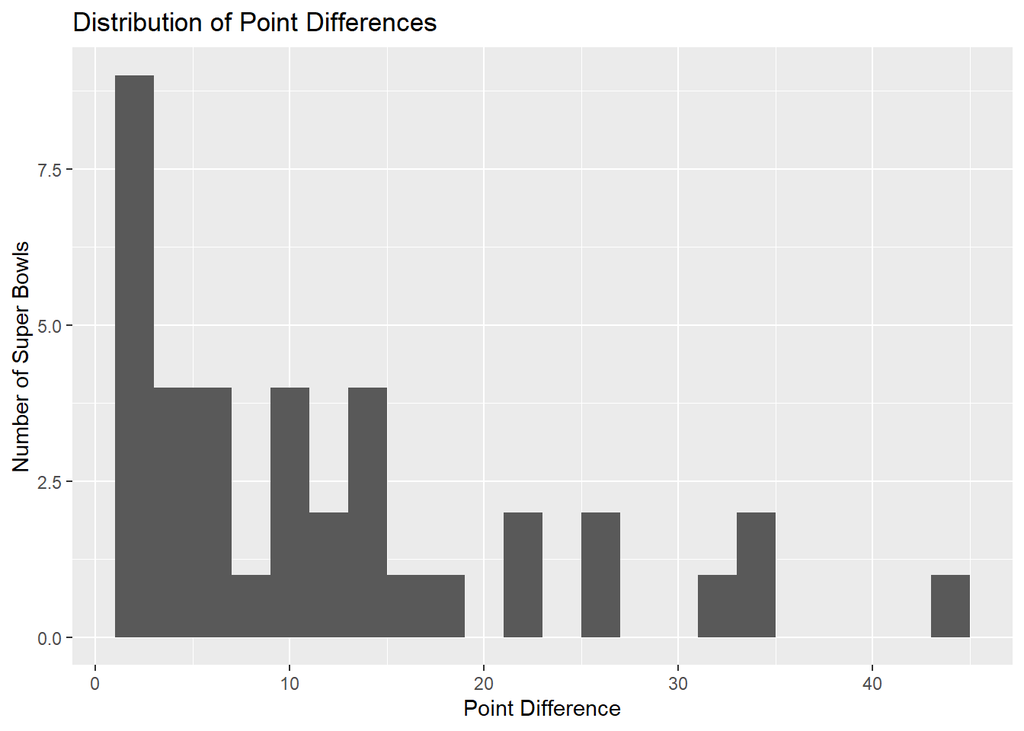

```r
ggplot(modern_superbowl, aes(difference_pts)) +
  geom_histogram(binwidth = 2) +
  labs(x = "Point Difference", y = "Number of Super Bowls",
       title = "Distribution of Point Differences")
```

*Interpretation:*

- This histogram shows how many modern Super Bowls ended with close scores versus blowouts.A small point difference indicates a close game, while a large difference indicates a more one-sided match.
- Close Games Are Common: The tall bars on the left suggest many modern Super Bowls ended with a relatively small point difference.
- Occasional Blowouts: The few, shorter bars on the far right indicate that while blowouts do happen, they’re not the norm in modern Super Bowls.

**Closest and Largest Point Difference Games**

```r
modern_superbowl %>%
  filter(difference_pts == min(difference_pts) | difference_pts == max(difference_pts))
```

```
## # A tibble: 2 × 18
##   date       super_bowl venue     city  state attendance team_winner winning_pts
##   <date>          <dbl> <chr>     <chr> <chr>      <dbl> <chr>             <dbl>
## 1 1991-01-27         25 Tampa St… Tampa Flor…      73813 New York G…          20
## 2 1990-01-28         24 Louisian… New … Loui…      72919 San Franci…          55
## # ℹ 10 more variables: qb_winner_1 <chr>, qb_winner_2 <chr>,
## #   coach_winner <chr>, team_loser <chr>, losing_pts <dbl>, qb_loser_1 <chr>,
## #   qb_loser_2 <chr>, coach_loser <chr>, combined_pts <dbl>,
## #   difference_pts <dbl>
```

**Scatter Plot: Point Difference vs Viewership**

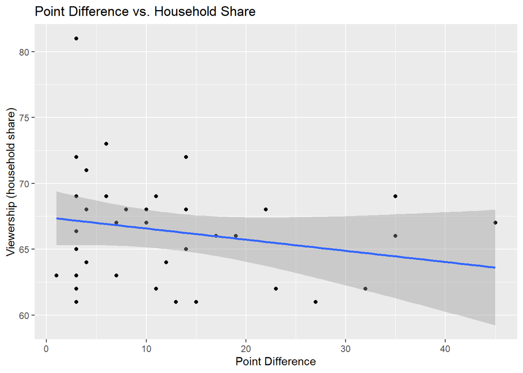

```r
# Merge game data with TV data
modern_games_tv <- modern_tv %>% inner_join(modern_superbowl, by = "super_bowl")

# Scatter plot with regression line
ggplot(modern_games_tv, aes(difference_pts, share_household)) +
  geom_point() +
  geom_smooth(method = "lm") +
  labs(x = "Point Difference", y = "Viewership (household share)",
       title = "Point Difference vs. Household Share")
```

*Interpretation*: The regression line suggests that larger point differences might lead to lower viewership, but the relationship is weak due to the limited data.

```r
score_impact = "weak"

score_impact
```

```
## [1] "weak"
```